# Exploratory Data Analysis

#### Get Correlation between different variables

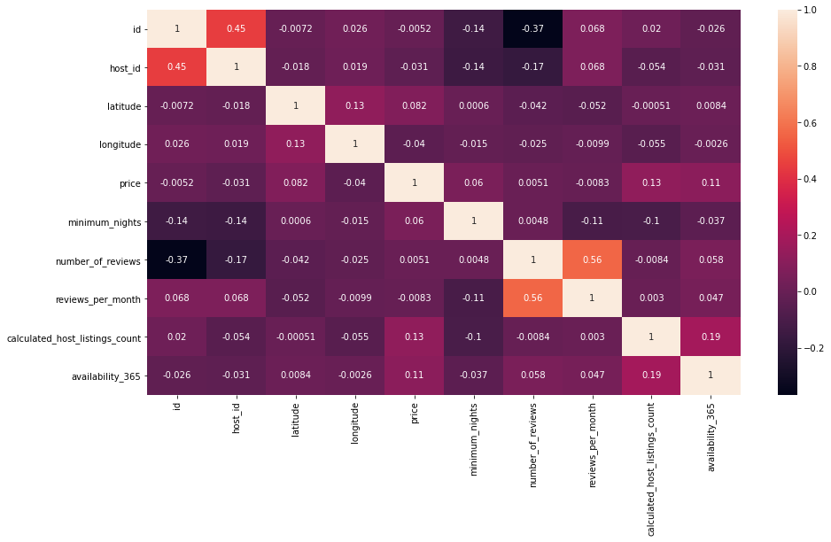

```python
corr = listings.corr(method='kendall')
plt.figure(figsize=(15,8))
sns.heatmap(corr, annot=True) ##call the heatmap from sns package
```

It's difficult to make conclusions with this correlation plot so I will transform the categorical variables neighbourhood_group' and 'room_type' as factors to aggregate them to my analysis.

```python
def Encode(listings):
    for column in listings.columns[listings.columns.isin(['neighbourhood_group', 'room_type'])]:
        listings[column] = listings[column].factorize()[0]
    return listings

listings_en = Encode(listings.copy())
```

```python
listings_en.head()
```

|  | id | host_id | neighbourhood_group | neighbourhood | latitude | longitude | room_type | price | minimum_nights | number_of_reviews | reviews_per_month | calculated_host_listings_count | availability_365 |
| --- | --- | --- | --- | --- | --- | --- | --- | --- | --- | --- | --- | --- | --- |
| 0 | 6369 | 13660 | 0 | Hispanoamerica | 40.45628 | -3.67763 | 0 | 70 | 1 | 65 | 0.56 | 1 | 53 |
| 1 | 21853 | 83531 | 1 | Carmenes | 40.40341 | -3.74084 | 0 | 17 | 4 | 33 | 0.55 | 2 | 48 |
| 2 | 24805 | 101471 | 2 | Universidad | 40.42202 | -3.70395 | 1 | 80 | 5 | 2 | 0.03 | 1 | 354 |
| 3 | 24836 | 101653 | 2 | Justicia | 40.41995 | -3.69764 | 1 | 115 | 3 | 64 | 0.63 | 1 | 301 |
| 4 | 26825 | 114340 | 3 | Legazpi | 40.38985 | -3.69011 | 0 | 25 | 2 | 136 | 1.19 | 1 | 337 |

```
Index(['id', 'host_id', 'neighbourhood_group', 'neighbourhood', 'latitude',
       'longitude', 'room_type', 'price', 'minimum_nights',
       'number_of_reviews', 'reviews_per_month',
       'calculated_host_listings_count', 'availability_365'],
      dtype='object')
```

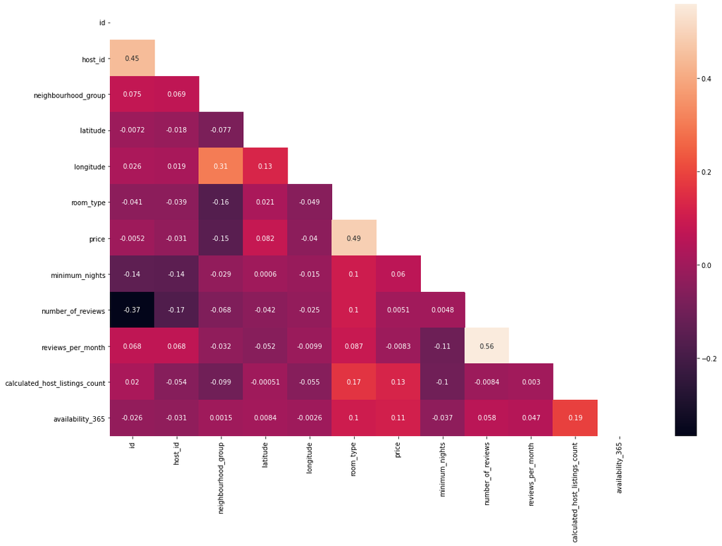

```python
mask = np.triu(np.ones_like(listings_en.corr(), dtype = bool)) #create mask for the upper triangle

plt.figure(figsize=(18,12))
corr = listings_en.corr(method='kendall') #Get Correlation between different variables

sns.heatmap(corr, annot=True, mask = mask)
listings_en.columns
```

With the above correlation graph, we can see that there is a positive correlation of 0.49 between price and room type that makes sense.

#### Distribution of the numerical variables

```python
list(set(listings.dtypes.tolist()))
```

```
[dtype('float64'), dtype('int64'), dtype('O')]
```

```python
listings_num = listings.select_dtypes(include = ['float64', 'int64'])
listings_num.head()
```

|  | id | host_id | latitude | longitude | price | minimum_nights | number_of_reviews | reviews_per_month | calculated_host_listings_count | availability_365 |
| --- | --- | --- | --- | --- | --- | --- | --- | --- | --- | --- |
| 0 | 6369 | 13660 | 40.45628 | -3.67763 | 70 | 1 | 65 | 0.56 | 1 | 53 |
| 1 | 21853 | 83531 | 40.40341 | -3.74084 | 17 | 4 | 33 | 0.55 | 2 | 48 |
| 2 | 24805 | 101471 | 40.42202 | -3.70395 | 80 | 5 | 2 | 0.03 | 1 | 354 |
| 3 | 24836 | 101653 | 40.41995 | -3.69764 | 115 | 3 | 64 | 0.63 | 1 | 301 |
| 4 | 26825 | 114340 | 40.38985 | -3.69011 | 25 | 2 | 136 | 1.19 | 1 | 337 |

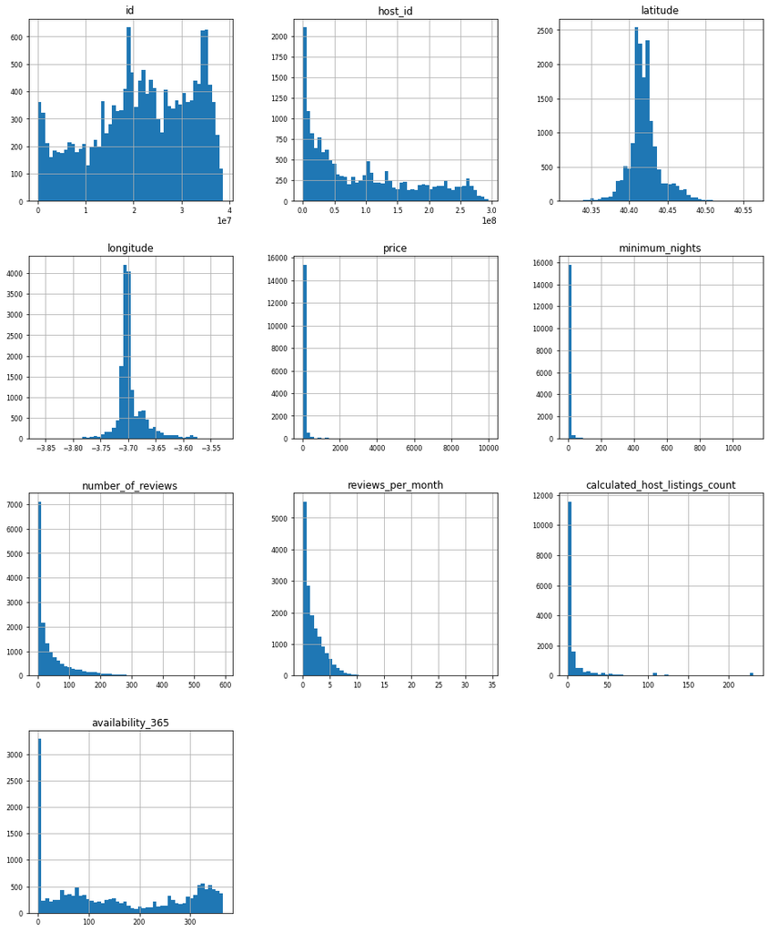

```python
listings_num.hist(figsize=(16, 20), bins=50, xlabelsize=8, ylabelsize=8); # ; avoid having the matplotlib verbose informations
```

### Detect and Remove the outliers

##### Z-Score

The Z-score is the signed number of standard deviations by which the value of an observation or data point is above the mean value of what is being observed or measured. The intuition behind Z-score is to describe any data point by finding their relationship with the Standard Deviation and Mean of the group of data points.

Well, while calculating the Z-score we re-scale and center the data and look for data points which are too far from zero. These data points which are way too far from zero will be treated as the outliers. In most of the cases a threshold of 3 or -3 is used i.e if the Z-score value is greater than or less than 3 or -3 respectively, that data point will be identified as outliers. We will use Z-score function defined in scipy library to detect the outliers.

```python
# from scipy import stats
# import numpy as np
z = np.abs(stats.zscore(listings_num))
print(z)
```

```
[[2.06056033 1.09028509 1.75259005 ... 0.71084452 0.33657966 0.79198602]
 [2.05908844 1.08945015 0.79319205 ... 0.7159283  0.30413165 0.83049309]
 [2.05880783 1.08923577 0.1029117  ... 0.98028508 0.33657966 1.52613975]
 ...
 [1.60983056 1.65838932 1.40423753 ... 0.48715801 0.30413165 1.48763267]
 [1.61520908 1.76041557 0.3554928  ... 0.48715801 0.33657966 0.56346294]
 [1.61742918 1.94348007 4.83456695 ... 0.48715801 0.33657966 0.96141713]]
```

Looking the code and the output above, it is difficult to say which data point is an outlier. Let’s try and define a threshold to identify an outlier.

```python
threshold = 3
print(np.where(z > 3))
```

```
(array([   24,    26,    31, ..., 16157, 16162, 16170]), array([6, 2, 2, ..., 2, 2, 2]))
```

The first array contains the list of row numbers and second array respective column numbers, which mean z[24][6] have a Z-score higher than 3.

```python
listings_filtered = listings_num[(z < 3).all(axis=1)] #can be remove the outliers with just one line code as we have already calculated the Z-score.
```

```python
listings_filtered.shape #check the results
```

```
(14435, 10)
```

##### Price distribution with the filtered data frame

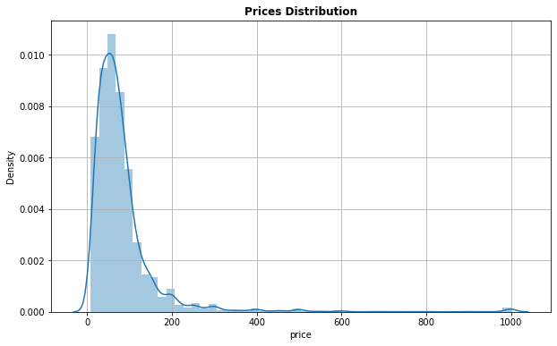

```python
plt.figure(figsize=(10,6))
sns.distplot(listings_filtered['price'])
plt.title('Prices Distribution', weight='bold')
plt.grid()
warnings.filterwarnings("ignore")
plt.show()
```

#### Map of room type

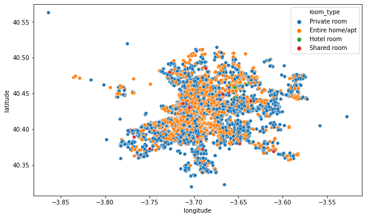

```python
plt.figure(figsize=(10,6))
sns.scatterplot(listings.longitude,listings.latitude,hue=listings.room_type)
plt.ioff()
```

#### Availability of Rooms

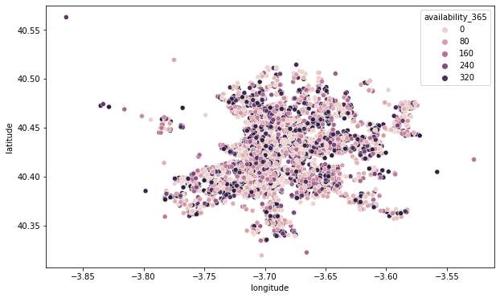

```python
plt.figure(figsize=(10,6))
sns.scatterplot(listings.longitude,listings.latitude,hue=listings.availability_365)
plt.ioff()
```

## Profile Report with Pandas Profiling package

```python
profile = ProfileReport(listings, title="Pandas Profiling Report")
profile.to_file(output_file="Pandas Profiling Report — AirBNB.html")

#I made my first profile report
```

# References

https://towardsdatascience.com/exploratory-data-analysis-eda-python-87178e35b14

https://www.kaggle.com/rusiano/madrid-airbnb-data

https://www.kaggle.com/ekami66/detailed-exploratory-data-analysis-with-python

https://seaborn.pydata.org/tutorial/distributions.html

https://towardsdatascience.com/histograms-and-density-plots-in-python-f6bda88f5ac0

https://www.interactivechaos.com/manual/tutorial-de-seaborn/presentacion

https://towardsdatascience.com/ways-to-detect-and-remove-the-outliers-404d16608dba